# 0.1 Overview

## You have a protein name.

### How do you download the data from PDB?

### How do you find patterns in amino acid sequence?

### How do you find the largest region of overlap between your protein and another protein?

# 0.2 Specific programming related objectives

1. What kind of language is `python`?
2. Downloading a `python` package
3. Data types (`int`, `float`, `str`, `bool`, `list`, `dict`)
4. Math
5. Flow control elements (`for` loop, `if`, `break`, `continue`)
6. Plots (line plot, histogram, colors, axis labels, legend)
7. Doing `MATLAB` or `R` stuff in Python
8. When to not use `python`

# 1. Why Python?

[figure not shown]

## Open source, general purpose, interpreted language

## Easy to read, write (fast prototyping)

- Faster than MATLAB*, R*
- Great with strings
- Also do matrices, solving differential equations, interact with various databases, machine learning
- General purpose - Build websites, GUIs, games, etc.

## There is a package to solve your problem!

- Packages:Python::Plugins:Firefox/Chrome
- `pip install <packagename>` e.g. `pip install numpy`

# 2. How to start with Python?

## Download a distribution (e.g. Anaconda)

- Anaconda = `python` + common packages (Anaconda:`python`::macOS:Linux)

## Start a Jupyter Notebook

- With Anaconda Navigator
- Or, open up Anaconda prompt and type `jupyter notebook`

## Start coding!

# 4. Jupyter notebooks

# DEMO

## 4.1 Code + explanation in one place using Markdown

[figure not shown]

## 4.2 Markdown rendered

[figure not shown]

## 4.3 Convert to other format easily

[figure not shown]

- Some formats may need LaTeX installed

# 5. Basic data types and syntax

## 5.1 Integers (`int`) & Floats (`float`)

Basically, numbers

```python
example_int = 2
print(example_int)
```

```
2
```

```python
example_float = 2.0
print(example_float)
```

```
2.0
```

```python
print(type(example_int), type(example_float))
```

```
<class 'int'> <class 'float'>
```

```python
x = example_int + example_float
print(x, type(x))
```

```
4.0 <class 'float'>
```

## 5.1.2 Basic math

```python
num1 = 1e-1  # use e-1 to multiple by 10^{-1}
num2 = 2  # spaces are not necessary, but nice
print(num1 + num2)  # Addition
print(num1 - num2, num1 * num2)  # Subtraction and multiplication
print(num1 * 2.3)
```

```
2.1
-1.9 0.2
0.22999999999999998
```

```python
print(3 / 2, 3 / 2.0)  # Dividing by int is same as dividing by float
```

```
1.5 1.5
```

```python
print(7//4, 7%4)  # Get quotient with // and remainder with percent sign
```

```
1 3
```

```python
print(2**5)  # Raise to power with **
```

```
32
```

## 5.1.3 Mathematical functions

First import the `math` library, and call functions with `math.exp(2)` or `math.sin(3)`. Or the `numpy` package if you have it installed

```python
import math
print(math.sin(math.pi))  # why is not zero?
import numpy as np  # np is shorthand for numpy, so you don't have to type it out
print(np.sin(np.pi))  # `np` is a shorthand, pick your own!
```

```
1.2246467991473532e-16
1.2246467991473532e-16
```

Why is it not zero?

### Exercise

```python
x = 2
y = 5 # Replace the hardcoded value
assert(abs(y - 5.251636631000412) < 1e-3)  # note that `abs` is a native function, not using `math.abs`
```

```
---------------------------------------------------------------------------
AssertionError                            Traceback (most recent call last)
<ipython-input-10-a9ae4fd7fdbe> in <module>
      1 x = 2
      2 y = 5 # Replace the hardcoded value
----> 3 assert(abs(y - 5.251636631000412) < 1e-3)  # note that `abs` is a native function, not using `math.abs`

AssertionError:
```

## 5.2 String (`str`)

- Can be enclosed in single or double quotes

```python
example_str = "abcde"
example_str2 = 'abcde'
print("Example_str : ", example_str)
print("Example_str2 : ", example_str2)
print(example_str[1], type(example_str[0]))
```

```
Example_str :  abcde
Example_str2 :  abcde
b <class 'str'>
```

### Exercise

Access the middle 3 letters of `example_str` and store it in `temp_str`

```python
temp_str = "bcd" # Replace hardcoded value
assert(temp_str == "bcd")
```

```python
print(example_str.capitalize() + " string capitalization and addition")
```

```
Abcde string capitalization and addition
```

### Look at help with (demo this + web):

```python
help(str)
```

[output not shown]

[output cut: 218 more lines]

[output not shown]

## 5.3 List (`list`)

For collections of things

```python
example_list = [1, 2.0, "c"]  # Elements of don't have to be same type
print(example_list, type(example_list))
print("Length of list is : ", len(example_list))  # Note that `len` returns `int`
```

```
[1, 2.0, 'c'] <class 'list'>
Length of list is :  3
```

```python
example_list.append(421323)
example_list2 = example_list + [1,1,1,1,1,1]
print(f"Example list is : {example_list}")
print(f"Example list 2 is : {example_list2}")
```

```
Example list is : [1, 2.0, 'c', 421323]
Example list 2 is : [1, 2.0, 'c', 421323, 1, 1, 1, 1, 1, 1]
```

### Exercise

Count the number of `1`s in the list `example_list2` programmatically. (Hint: use `help(list)`)

```python
y = 2  # Replace hardcoded value
assert(y - 7 == 0)
```

```
---------------------------------------------------------------------------
AssertionError                            Traceback (most recent call last)
<ipython-input-17-3ce06a0197b0> in <module>
      1 y = 2  # Replace hardcoded value
----> 2 assert(y - 7 == 0)

AssertionError:
```

## 5.4 Boolean (`bool`)

Either `True` or `False`

```python
print(2 == 2.0)
print("Type of an equality check is : ", type(2==2.0))
```

```
True
Type of an equality check is :  <class 'bool'>
```

```python
example_list = [1,2,3]
print(example_list[2] == "v")
print("Converting a False bool to an integer : ", int(example_list[2] == "v"))
```

```
False
Converting a False bool to an integer :  0
```

### 5.4.1 Boolean operators (`and`, `or`)

Readability!! No `||` or `&`

```python
print((example_list[1] == 2) and (example_list[2] == 3))
print((example_list[1] == 2) or (example_list[2] == 3321))
```

```
True
True
```

## 5.5 Dictionary (`dict`)

### Key-value pairs: Like a 2 column table

- First column - `key`, should be unique
- Second column - `value`, can be (almost) any datatype

```python
example_dict = {1:"one", 2:"two", "pi":3.1417}  # Create a dictionary
example_dict["e"] = 2.73 # Add elements
print(example_dict[1], " and ", example_dict["pi"])
```

```
one  and  3.1417
```

#### Get all keys with `dict.keys()`, values with `dict.values()`

```python
print("Keys are : ", example_dict.keys(), type(example_dict.keys()))
print("Values are : ", example_dict.values(), type(example_dict.values()))
```

```
Keys are :  dict_keys([1, 2, 'pi', 'e']) <class 'dict_keys'>
Values are :  dict_values(['one', 'two', 3.1417, 2.73]) <class 'dict_values'>
```

### Exercise

```python
example_list = ["pi", "e", "c", "G"]
required_value = 0  # Replace hardcoded value
assert(required_value-3.1417 == 0)
```

```
---------------------------------------------------------------------------
AssertionError                            Traceback (most recent call last)
<ipython-input-23-d88299816ffe> in <module>
      1 example_list = ["pi", "e", "c", "G"]
      2 required_value = 0  # Replace hardcoded value
----> 3 assert(required_value-3.1417 == 0)

AssertionError:
```

## 5.6 Flow control statements

Syntax uses white spaces, no excessive brackets etc for readability

**DO NOT MIX TABS AND SPACES**

### 5.6.1 `if-else`

```python
x = 1
if x == 1:
    print("x was 1!")
elif (x == "cat"):
    print("meow")
else:
    print("output of else")
```

```
x was 1!
```

### 5.6.2 `for` loop

- `range(n)` gives integer from **[0,1,...,n)**
- Can also specify non-zero start points and jump size: how? Try `help(range)`!

```python
for loop_index in range(3):
    print("Loop index is : ", loop_index)
```

```
Loop index is :  0
Loop index is :  1
Loop index is :  2
```

- Can be used to move through a list

```python
example_list = ["a", "b", "c"]
for item in example_list:
    print("Item is : ", item)
print("------------")
```

```
Item is :  a
Item is :  b
Item is :  c
------------
```

### Exercise

Make a two lists: one of the odd numbers and one of the even numbers with each number satisfying $2\le n \le 9$. Use `for` and `list.append`.

```python
odd = []
even = []
# insert loop here
assert(odd == [3,5,7,9])
assert(even == [2,4,6,8])
```

```
---------------------------------------------------------------------------
AssertionError                            Traceback (most recent call last)
<ipython-input-27-73b01372da73> in <module>
      2 even = []
      3 # insert loop here
----> 4 assert(odd == [3,5,7,9])
      5 assert(even == [2,4,6,8])

AssertionError:
```

### 5.6.3 `break` and `continue`

- `break` skips the reaminder of the current iteration + all future iterations
- `continue` skips the remainder of the current iteration

```python
for ind in range(10):
    if ind < 2:
        print(f"ind = {ind}, continuing")
        continue
    elif ind > 3:
        print(f"ind = {ind}, breaking")
        break
    print(f"ind = {ind}, doing nothing")
print("Loop has ended")
```

```
ind = 0, continuing
ind = 1, continuing
ind = 2, doing nothing
ind = 3, doing nothing
ind = 4, breaking
Loop has ended
```

# 6 Functions

```python
def add(a, b):
    y = a + b
    return y

print(add(2, 3), type(add), add)
print("Changing argument order : ", add(b=3, a=2))
print("Calling add function with lists : ", add([2,3], [6,7]))
```

```
5 <class 'function'> <function add at 0x000002AB3F719B70>
Changing argument order :  5
Calling add function with lists :  [2, 3, 6, 7]
```

## 6.1 Default arguments

```python
def sub(a, b=2):
    return a - b
print("Specifying both arguments : ", sub(11, 7))
print("Specifying only one argument : ", sub(9))
print("Specifying only one argument with keyword : ", sub(a=9))
# Uncomment the following lines and try
# def sub2(a=2, b):
#     return a - b
```

```
Specifying both arguments :  4
Specifying only one argument :  7
Specifying only one argument with keyword :  7
```

### Exercise

Write a function `prodlist` that accepts a list and returns the product of all the elements in that list. You can assume that the list has `float` or `int` types.

```python
assert (prodlist([1,2,3] == 6))
```

```
---------------------------------------------------------------------------
NameError                                 Traceback (most recent call last)
<ipython-input-31-c822f0c0e92a> in <module>
----> 1 assert (prodlist([1,2,3] == 6))

NameError: name 'prodlist' is not defined
```

## 6.2 Return types can be anything

```python
import math

def my_func(x):
    if x == 1:
        return "one"
    elif x == 2:
        return [2, "two"]
    elif x == 3:
        return  math.sin

print("Calling with argument 3!")
return_value = my_func(3)
print("Returned value is : ", return_value)
print("Returned type is : ", type(return_value))
```

```
Calling with argument 3!
Returned value is :  <built-in function sin>
Returned type is :  <class 'builtin_function_or_method'>
```

# 7.1 Basic plotting

- `matplotlib` is the plotting library

First define the data used for plotting

```python
Tc = list(range(0,100,5))
Tf, Tf_incorrect = [], []
for ind in range(len(Tc)):
    this_Tf = 9/5 * Tc[ind] + 32
    Tf.append(this_Tf)
    Tf_incorrect.append(this_Tf*1.15)
```

## 7.1.1 Line plots

```python
import matplotlib.pyplot as plt

# Call plt.plot with x and y arguments. Also provide `color`, `marker`, `linestyle` and `label`.
# `label` shows up in legend`
plt.plot(Tc, Tf, color="green", marker="o", linestyle= ":", label="Correct")
plt.plot(Tc, Tf_incorrect, "rx", label="Incorrect")  # plot the incorrect Fahrenheit
plt.xlabel("Temperature ($^o$C)")  # set x label
plt.ylabel("Temperature ($^o$F)")  # set y label
plt.legend()  # Make the legend appear
plt.show()
```

[output not shown]

## 7.1.2 Histograms

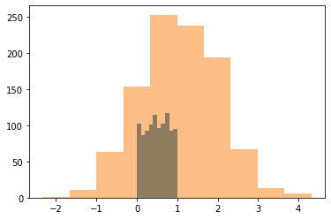

```python
import random
x1 = []
x2 = []
random.seed(10)  # for reproducibility
for ind in range(1000):
    x1.append(random.random())
    x2.append(random.normalvariate(mu=1, sigma=1))
plt.hist(x1);
plt.hist(x2, alpha=0.5);
```

# 8.1 `python` for `MATLAB` users

## Counting starts with 0 in `python`, 1 in `MATLAB`

## `numpy` - basic matrix functionality

https://docs.scipy.org/doc/numpy/user/numpy-for-matlab-users.html

## `scipy` - advanced math functions, optimization, differential equations

```python
import numpy as np

x = np.zeros([2, 3])
print(x)
```

```
[[0. 0. 0.]
 [0. 0. 0.]]
```

## 8.1.1 Solve and plot a differential equation

To solve the following differential equation:

$$dh/dt = -r_1 h -r_2 h$$$$di/dt = r_2 h + r_3 I (I_{max}-I)$$

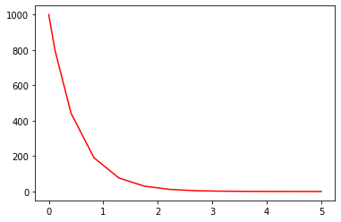

```python
from scipy.integrate import solve_ivp
def twocomp_model(t, y, p) -> float:
    dhdt = -p["r1"] * y[0] - p["r2"] * y[0]
    didt = p["r2"] * y[0] + p["r3"] * y[1] * (p["Imax"]  - y[1])
    return [dhdt, didt]
tlist, y0 = [0, 5], [1000, 0]
pars = {"r1":1.0, "r2":1.0, "r3":0.001, "Imax":3000} # dictionary of parameters
sol = solve_ivp(lambda t, y: twocomp_model(t, y, pars), tlist, y0)
plt.plot(sol.t, sol.y[0,:], "red", label="h");
```

# 8.2 `python` for `R` users

## Counting starts with 0 in `python`, 1 in `R`

## `pandas` - dataframes

```python
import pandas as pd
df = pd.DataFrame(np.random.randn(4, 2), index=[1,2,3,4], columns=list('AB'))
df
```

|  | A | B |
| --- | --- | --- |
| 1 | 0.689940 | 0.942907 |
| 2 | 0.282064 | 0.801016 |
| 3 | 0.686383 | -0.503279 |
| 4 | -1.454698 | -0.171765 |

```python
df["A"]
```

```
1    0.689940
2    0.282064
3    0.686383
4   -1.454698
Name: A, dtype: float64
```

# 9. Python 2 vs 3

- 3.x is current
- Support 2.x will stop by 2020
- Some older packages may only work with 2.x

## Key differences

| Py2 | Py3 |
| --- | --- |
| `print "this is a string"` | `print("this is a string")` |
| `3/2` evaluates to `1`, of type `int` | `3/2` evaluates to `1.5`, of type `float` |

# 10. Why not python?

## Slower than C, C++, Julia

- `numba` - magically compiles Python -> C (like `MATLAB Coder`)
- `Cython` - intermediate language with more fine-grained control
- C extensions - actual C code used by Python (like `Rcpp` in `R` and `mex` in `MATLAB`)

## Package and python version conflicts

- Virtual environments
- `pipenv`

## Fewer statistical packages

- Use `R` for uncommon statistical tests, easier interface

## You prefer GUIs to coding

- Use the `MATLAB` toolbox GUIs

# A. Assignment

## A1.1 Obtain PDB File

Fill up the following function skeleton:

```
def get_pdb_file(): # insert arguments
    print() # make print output match
    # generalize the following variables
    file_url = "https://files.rcsb.org/download/zzzz.pdb"
    download_file_name = "zzzz.pdb"
    urllib.request.urlretrieve(file_url, download_file_name) # don't modify
    print() # make print output match
    with open(download_file_name) as file_handle: # don't modify
        data = file_handle.read() # don't modify
        lines = ___ # get a list of lines
    print() # make print output match, print first line of file
```

Expected output on the next page.

### Expected outputs

When you call `get_pdb_file` as follows:

```
get_pdb_file("3SJU")
```

you get the following output:

```
Going to download : 3SJU
Downloaded 3SJU.pdb
The first line is : HEADER    OXIDOREDUCTASE                          21-JUN-11   3SJU
```

## A2.1 Process file and plot amino acid frequencies

The final plot should look like this:

[figure not shown]

Hints on the next page.

### Hints

- Use the following list

```
x = ["Ala", "Arg", "Asn", "Asp", "Cys", "Glu", "Gly", "His",
    "Ile", "Leu", "Lys", "Met", "Phe", "Pro", "Ser", "Thr",
    "Trp", "Tyr", "Val"]
```

- One way : Extract the amino acids from the `.pdb` file using `with open...`, `str.startswith()`, `str.split()` and `str.capitalize()`. Assign to a list. The output should look something like:

```
all_aa = ["Met", "Gly", "Ser"...]
```

- Use the following function to get the counts of the amino acids.

```
def get_counts(aa_list):
    y = []
    for an_aa in x:
        y.append(aa_list.count(an_aa))
    return y
```

## A2.2 Use single letter amino acid labels on X axis

The final plot should look like this:

[figure not shown]

Use the dictionary below

```
aa_dict = {"ala":"A", "arg":"R", "asn":"N", "asp":"D", "asx":"B", "cys":"C", "glu":"E",
           "gln":"Q","glx":"Z","gly":"G", "his":"H", "ile":"I","leu":"L", "lys":"K", "met":"M",
           "phe":"F", "pro":"P", "ser":"S", "thr":"T", "trp":"W", "tyr":"Y", "val":"V"}
```

## A2.3 (challenge) Overlay frequencies at odd and even positions + legend

Overlay two frequency plots, one of the amino acids in the even positions and another of amino acids in the odd positions. For example, if the amino acids are :

```
aa = ["Gly", "Ala", "Val", "Leu", "Ile", "Cys"]
```

Then make histogram of the following two lists:

```
aa_odd = ["Gly", "Val", "Ile"]
aa_even = ["Ala", "Leu", "Cys"]
```

Final plot + hints on the next page.

### Final plot

[figure not shown]

### Hints

1. Use the `get_counts` function defined earlier.

# Longest Common Subsequence

Given two different protein or DNA sequences, biologists wish to determine how similar they are. Higher similarity indicates closer evolutionary relationship between the 2 proteins or DNA. One measure of similarity is the length of the longest common subsequence (LCS).

So what is LCS? If we delete some characters from string x and some characters from string y, and the resulting two strings are equal, we call the resulting string a common subsequence. The LCS is the longest common subsequence of two strings. For example, take two strings `"xabcfghiy"` and `"mabcdefghij"`. The longest common subsequence is `"abcfghi"`.

Solving LCS problem is not an easy task, which requires advanced algorithmic knowledge called dynamic programming. Classic algorithms for LCS problem such as Needleman-Wunsch algorithm and Smith-Waterman algorithm are all based on this scheme. In this assignment, you are not expected to write the algorithm by yourself, instead, use the provided module `LongestCommonSubsequence.py` as follows:

##### Continued

```
from LongestCommonSubsequence import lcs
```

Now you are able to use the `lcs()` function. Read the signature and docstring of the function first:

```
def lcs(str1, str2, m, n):
    '''Dynamic programming implementation of longest common subsequences
    (LCS) problem, print the LCS as while as the length of the LCS
    Parameters
    ----------
    str1 : str
        The first target string
    str2 : str
        The second target string
    m : int
        The length of str1
    n : int
        The length of str2
    '''
```

1. Download the proteins `3SJU` and `1X7H`.
2. Use `LongestCommonSubsequence.py` to find the longest common subsequence. You are expected to see the following output:

```
The LCS is MSVAVTGSGIGLARRGGRVVGLRAGVDGCDVSVAVAAVERGPLVNAGRGGGTALALWLDT…
Length of the LCS is 334
```

### Hint

- Make sure `LongestCommonSubsequence.py` is in the current directory!
- You need to convert the 3 letter sequence to the 1 letter subsequence to use the function.

# Appendix

## Create a virtual environment

- Avoid confusion with `python` that Linux/macOS need to run
- Work on different `python` versions
  - This module uses `python 3.6+`
- Keep different projects separate

# 3.1 Modes of Python

## Code files

[figure not shown]

- Long and involved projects
- Submitting jobs on cluster

# 3.2

## REPL

[figure not shown]

- Read-Eval-Print Loop
- Very fast prototyping, especially on cluster etc

# 3.3

## (Jupyter) Notebooks

[figure not shown]

- REPL + Markdown
- Share with others who want to see your code, write reports
- Reproducible research
- Works with dozens of languages including MATLAB, Mathematica, etc (see https://github.com/jupyter/jupyter/wiki/Jupyter-kernels)

# 3.4

## Choosing a mode

| Mode | When to use | When not to use |
| --- | --- | --- |
| Code files | - Long and involved codes - Submitting jobs on cluster | Fast prototyping |
| REPL | Very fast prototyping | Any serious work |
| (Jupyter) notebooks | - Fast prototyping - Embed links, images | Long and involved codes |

## 4.4 Working with Jupyter

### 4.4.1 Start a Jupyter notebook

From command line, do

```
jupyter notebook
```

### 4.4.2 Jupyter notebook and virtual environments

#### Virtual environments

- To keep separate projects separate
- Each virtual environment has:
  - Own version of `python` installed
  - Own set of packages
- Virtual environment:Python :: User:Windows

#### Creating a virtual environment

Type the following in a terminal

```
conda create -n myenv python=3.6  # Creates enviroment
conda activate myenv  # Activates environment for use
```

#### Make Jupyter notebook use your virtual environment

1. Activate your virtual environment, suppose it's called `myenv`.
2. Install the `ipykernel` package with `--user` flag.
3. Install a kernel using `ipykernel`.

```
conda activate myenv
pip install --user ipykernel
python -m ipykernel install --user --name=myenv_kernel
```

## 4.5 Jupyter and version control

### Option 1: Notebook format, `.ipynb`

- `json` format
- More verbose

### Option 2: Convert to Rmarkdown format, `.Rmd`

- Less verbose
- Must convert back and forth

First install `jupytext package`

```
pip install jupytext
```

Conversions to and from `.Rmd`

```
jupytext --to ipynb notebook.Rmd   # convert Rmd to ipynb
jupytext --to rmarkdown notebook.ipynb   # convert ipynb to Rmd
```